# Homework12_Palashi_Singhal

1. Describe how you would determine whether cat images and applesauce flavor are a good/bad idea. Be specific in what you would do, how you would set up data collection, what tests you would run, and how you would transform statistical significance into actionable conclusions.

Do determine if cat images and apple sauce flavor are a good/bad idea, I would conduct a survey analysis targeting a specific grouo of people, who I think woud be ideal for to test this product, and the questions would be based on the product design, which would have questions about the packaging, the name, and the overall product appeal. The survey questions could be designed on a 5 point likert scale, and each parameter would have questions assessing the perception of the customer. The dependent variable here would be the overall product appeal/design, and the independant variables would be the packaging, idea (applesauce flavor and cat images), taste and personal preferances (which would affect all other responses) Then I would run a significance analysis to see whether the idea is or bad (the positive responses should be more significantly more than the negative reponses ) and a linear regression to see which of the following variables have the most positive effect on product design. The null hypothesis in this case would be that the applesauce flavor and cat images, donot have any positive effect on the target consumer. Hence these tests, could give us actionable conclusions, to give feedback to the design team.

2. How would you determine the sample size needed to conduct the experiment?

The sample size for the experiment can be calculated by conducting power analysis, by fixating a effect size and a desired power level we need. The effect size would tell us, how much of a positive effect we would want to see from the apple sauce flavor and the cat images packing, and the power we would want is more than 80%, which is the standardized power needed for all BeSci work.

3. What data cleaning activities would you have to conduct to be able to work with data?

Data Cleaning activities : Having a clean and workable dataset would be the first priority, then I would remove all NA values, where it not required, and have separate columns for independant and dependant variables. Further, for performong analysis, I would have to combine all survey questions asked under one variable into one column, so that I can perform regressions.

4. Simulate the dataset. You need to create several variables (at least 4), populate them with synthetic data, introduce random noise and incorporate correlations between variables that you believe will be observed.

```r
library(car)
library(MASS)
library(lmtest)
library(tseries)
library(ggfortify)
set.seed(1234)

##Linear Regression
#Generate the independent variable and the error
x1=rnorm(100,50,9)
x2=rnorm(100,200,64)
x3=rnorm(100,100,16)
x4=rnorm(100,200,36)
error=rnorm(100,0,16)
#Generate the dependent variable (b0=150, b1=-4, b2=2.5)
y1=150-(4*x1)+(2.5*x2)+ (3*x3)+ (2*x4) + error
#create the model
m1=lm(y1~x1+x2+x3+x4)
summary(m1)
```

```
##
## Call:
## lm(formula = y1 ~ x1 + x2 + x3 + x4)
##
## Residuals:
##     Min      1Q  Median      3Q     Max
## -40.282 -13.201  -0.418  10.685  54.170
##
## Coefficients:
##              Estimate Std. Error t value Pr(>|t|)
## (Intercept) 159.42202   17.44403   9.139 1.14e-14 ***
## x1           -4.11995    0.20422 -20.174  < 2e-16 ***
## x2            2.50037    0.02798  89.357  < 2e-16 ***
## x3            3.04635    0.11941  25.512  < 2e-16 ***
## x4            1.95610    0.04917  39.779  < 2e-16 ***
## ---
## Signif. codes:  0 '***' 0.001 '**' 0.01 '*' 0.05 '.' 0.1 ' ' 1
##
## Residual standard error: 18.1 on 95 degrees of freedom
## Multiple R-squared:  0.9924, Adjusted R-squared:  0.992
## F-statistic:  3085 on 4 and 95 DF,  p-value: < 2.2e-16
```

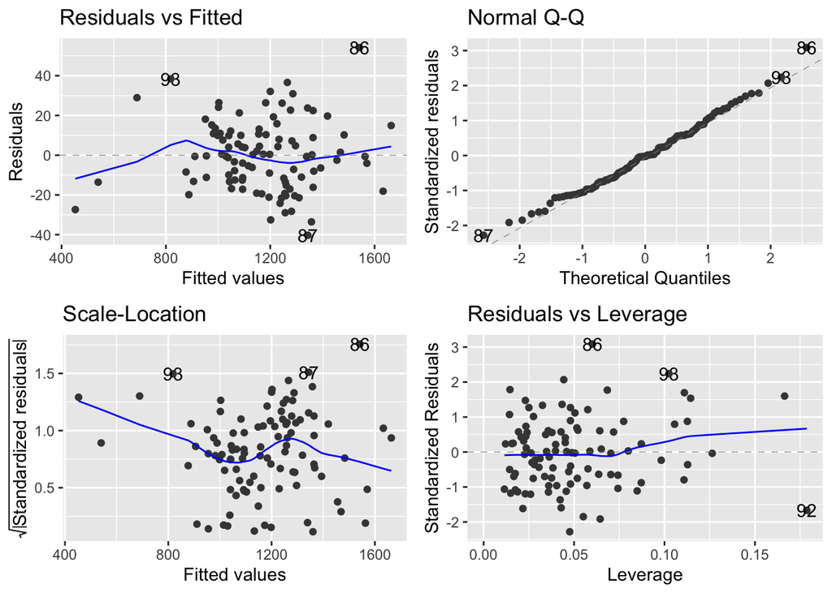

```r
autoplot(m1)
```

5. Show with the code how you would conduct the analyses. Confirm that your analyses reveal the patterns you simulated in Q4 (for example, if you assumed that a 1-unit change in variable X leads to a 2-unit change in variable Y, you should be able to demonstrate it here).